# Practical Machine Learning - Assignment

Using devices such as Jawbone Up, Nike FuelBand, and Fitbit it is now possible to collect a large amount of data about personal activity relatively inexpensively. These type of devices are part of the quantified self movement – a group of enthusiasts who take measurements about themselves regularly to improve their health, to find patterns in their behavior, or because they are tech geeks. One thing that people regularly do is quantify how much of a particular activity they do, but they rarely quantify how well they do it. In this project, your goal will be to use data from accelerometers on the belt, forearm, arm, and dumbell of 6 participants. They were asked to perform barbell lifts correctly and incorrectly in 5 different ways. This project will take the Weight Lifting Exercise data set and attempt to create a predictive model for the six people performing exercies both correctly and incorrectly. The raw activity data will be cleaned, parsed and then used in a predictive model. #Data processing and analysis Download the initial data and the required libraries. Add the libraries to take advantage of multiple cores. Experience has shown that using all cores of a system can cause instability. Read the data into datasets and take a quick look at the data.

```r
setwd("~/Coursera/datasci-predmachlearn")
library(corrplot) ;library(caret) ;library(kernlab);library(randomForest);library(rpart)
library(doMC);registerDoMC(cores=3)
#download the data - don't do it if you already have it
if(!file.exists("./pml-testing.csv")){
fileURL<-"https://d396qusza40orc.cloudfront.net/predmachlearn/pml-training.csv"
download.file(fileUrl,destfile="./pml-training.csv",method="curl")
}
if(!file.exists("./pml-testing.csv")){
fileURL<-"https://d396qusza40orc.cloudfront.net/predmachlearn/pml-testing.csv"
download.file(fileUrl,destfile="./pml-testing.csv",method="curl")
}
# Put the data into initial datasets - still want to do this because the dataset may have been corrupted, or updated, with unwanted values.
testingall<-read.csv("./pml-testing.csv")
trainingall<-read.csv("./pml-training.csv")
# create training & testing from training
```

Start with simple exploratory data analysis (EDA) to look at the data. For the model we will be attempting to reduce the number of variables so will be tracking that through the cleaning and parsing process.

```r
length(trainingall);str(trainingall)
```

```
## [1] 160
```

```
## 'data.frame':    19622 obs. of  160 variables:
##  $ X                       : int  1 2 3 4 5 6 7 8 9 10 ...
##  $ user_name               : Factor w/ 6 levels "adelmo","carlitos",..: 2 2 2 2 2 2 2 2 2 2 ...
##  $ raw_timestamp_part_1    : int  1323084231 1323084231 1323084231 1323084232 1323084232 1323084232 1323084232 1323084232 1323084232 1323084232 ...
##  $ raw_timestamp_part_2    : int  788290 808298 820366 120339 196328 304277 368296 440390 484323 484434 ...
##  $ cvtd_timestamp          : Factor w/ 20 levels "02/12/2011 13:32",..: 9 9 9 9 9 9 9 9 9 9 ...
##  $ new_window              : Factor w/ 2 levels "no","yes": 1 1 1 1 1 1 1 1 1 1 ...
##  $ num_window              : int  11 11 11 12 12 12 12 12 12 12 ...
##  $ roll_belt               : num  1.41 1.41 1.42 1.48 1.48 1.45 1.42 1.42 1.43 1.45 ...
##  $ pitch_belt              : num  8.07 8.07 8.07 8.05 8.07 8.06 8.09 8.13 8.16 8.17 ...
##  $ yaw_belt                : num  -94.4 -94.4 -94.4 -94.4 -94.4 -94.4 -94.4 -94.4 -94.4 -94.4 ...
##  $ total_accel_belt        : int  3 3 3 3 3 3 3 3 3 3 ...
##  $ kurtosis_roll_belt      : Factor w/ 397 levels "","-0.016850",..: 1 1 1 1 1 1 1 1 1 1 ...
##  $ kurtosis_picth_belt     : Factor w/ 317 levels "","-0.021887",..: 1 1 1 1 1 1 1 1 1 1 ...
##  $ kurtosis_yaw_belt       : Factor w/ 2 levels "","#DIV/0!": 1 1 1 1 1 1 1 1 1 1 ...
```

[output cut: 86 more lines]

```r
# del columns
delCol<-grepl("X|user_name|timestamp|new_window|num_window",colnames(trainingall))
training<-trainingall[,!delCol]
testing<-testingall[,!delCol]
# get rid of zero columns
NA_Col <- colSums(is.na(training))
FlagCol <- NA_Col == 0
trainmid <- training[FlagCol]
testmid <- testing[FlagCol]
#get rid of near zero variables
nzv1 <- nearZeroVar(trainmid,saveMetrics=TRUE)
trainfinal <- trainmid[,nzv1$nzv==FALSE]
nzv2<-nzv1[-28,]
testfinal <- testmid[,nzv1$nzv==FALSE]

# look at final columns and confirm that test and train are the same.
str(trainfinal);dim(testfinal)
```

```
## 'data.frame':    19622 obs. of  53 variables:
##  $ roll_belt           : num  1.41 1.41 1.42 1.48 1.48 1.45 1.42 1.42 1.43 1.45 ...
##  $ pitch_belt          : num  8.07 8.07 8.07 8.05 8.07 8.06 8.09 8.13 8.16 8.17 ...
##  $ yaw_belt            : num  -94.4 -94.4 -94.4 -94.4 -94.4 -94.4 -94.4 -94.4 -94.4 -94.4 ...
##  $ total_accel_belt    : int  3 3 3 3 3 3 3 3 3 3 ...
##  $ gyros_belt_x        : num  0 0.02 0 0.02 0.02 0.02 0.02 0.02 0.02 0.03 ...
##  $ gyros_belt_y        : num  0 0 0 0 0.02 0 0 0 0 0 ...
##  $ gyros_belt_z        : num  -0.02 -0.02 -0.02 -0.03 -0.02 -0.02 -0.02 -0.02 -0.02 0 ...
##  $ accel_belt_x        : int  -21 -22 -20 -22 -21 -21 -22 -22 -20 -21 ...
##  $ accel_belt_y        : int  4 4 5 3 2 4 3 4 2 4 ...
##  $ accel_belt_z        : int  22 22 23 21 24 21 21 21 24 22 ...
##  $ magnet_belt_x       : int  -3 -7 -2 -6 -6 0 -4 -2 1 -3 ...
##  $ magnet_belt_y       : int  599 608 600 604 600 603 599 603 602 609 ...
##  $ magnet_belt_z       : int  -313 -311 -305 -310 -302 -312 -311 -313 -312 -308 ...
##  $ roll_arm            : num  -128 -128 -128 -128 -128 -128 -128 -128 -128 -128 ...
```

[output cut: 39 more lines]

```
## [1] 20 53
```

It is now time to separate the data into a training and testing set. Although there was a given testing set, that set does not have the response variable, so it can not be used for the actual creation and testing of our model. Divide the data into 70% for training and 30% for testing. Set a seed so that the model is repeatable. Check at end that I didn’t mess up columns.

```r
#partition the data
set.seed(12345)
inTrain<-createDataPartition(y=trainfinal$classe,p=.7,list=FALSE)
traintrain<-trainfinal[inTrain,]
traintest<-trainfinal[-inTrain,]
dim(traintrain);dim(traintest)
```

```
## [1] 13737    53
```

```
## [1] 5885   53
```

Now that we have a smaller set, we can take a quick look at the correlation matrix from the data. Heatmaps provide an excellent view of the data. The bright red, as shown in the cross bar where columns equal each other, show high correlation.

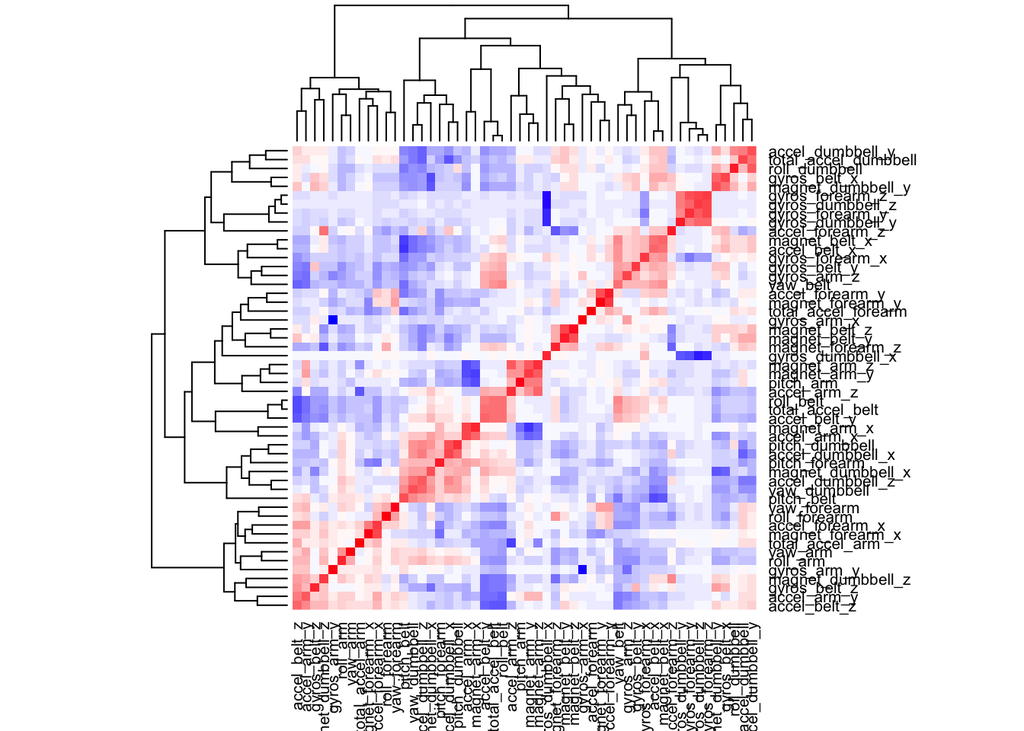

```r
pred.cor <- cor(traintrain[, names(traintrain) != "classe"])
pal <- colorRampPalette(c("blue", "white", "red"))(n=50)
heatmap(pred.cor, col = pal)
```

Although there are a few highly correlated factors we could work to remove some factors if the model runs too slowly or doesn’t provide good results. Let’s see how the model works first without any additional work. Now it is time to build the model. This will use a simple random forest model. However, we will add the cross validation three times to meet the task requirement. We will also allow parallelization to aid performance. Given the cleaned data and correlation results, we would expect a low error rate.

```r
model <- train(as.factor(traintrain$classe) ~ ., data = traintrain, method = "rf", prox = TRUE,
               trControl = trainControl(method = "cv", number = 3, allowParallel = TRUE))
#model <- train(as.factor(traintrain$classe) ~ ., data = traintrain, method = "rf")
#model1 <- randomForest(classe ~ ., data = traintrain, ntree = 1024)
```

OK, time to check the error estimate for the model.

```r
model$finalModel
```

```
##
## Call:
##  randomForest(x = x, y = y, mtry = param$mtry, proximity = TRUE)
##                Type of random forest: classification
##                      Number of trees: 500
## No. of variables tried at each split: 2
##
##         OOB estimate of  error rate: 0.64%
## Confusion matrix:
##      A    B    C    D    E class.error
## A 3904    2    0    0    0    0.000512
## B   14 2638    6    0    0    0.007524
## C    0   21 2372    3    0    0.010017
## D    0    0   32 2218    2    0.015098
## E    0    0    1    7 2517    0.003168
```

Now check the results using the test data set.

```r
#now check the model against the test data
traintestPred<- predict(model, traintest)
confusionMatrix(traintestPred,traintest$classe)
```

```
## Confusion Matrix and Statistics
##
##           Reference
## Prediction    A    B    C    D    E
##          A 1673   12    0    0    0
##          B    1 1122   13    0    0
##          C    0    5 1010   23    0
##          D    0    0    3  941    4
##          E    0    0    0    0 1078
##
## Overall Statistics
##
##                Accuracy : 0.99
##                  95% CI : (0.987, 0.992)
##     No Information Rate : 0.284
##     P-Value [Acc > NIR] : <2e-16
##
##                   Kappa : 0.987
##  Mcnemar's Test P-Value : NA
##
## Statistics by Class:
##
##                      Class: A Class: B Class: C Class: D Class: E
## Sensitivity             0.999    0.985    0.984    0.976    0.996
## Specificity             0.997    0.997    0.994    0.999    1.000
## Pos Pred Value          0.993    0.988    0.973    0.993    1.000
## Neg Pred Value          1.000    0.996    0.997    0.995    0.999
## Prevalence              0.284    0.194    0.174    0.164    0.184
## Detection Rate          0.284    0.191    0.172    0.160    0.183
## Detection Prevalence    0.286    0.193    0.176    0.161    0.183
## Balanced Accuracy       0.998    0.991    0.989    0.987    0.998
```

Since we have verified the model with the test data carved out of the training set and achieved fairly accurate results, we can now run the model against the provided test data.

```r
testPred<- predict(model, testfinal);testPred
```

```
##  [1] B A B A A E D B A A B C B A E E A B B B
## Levels: A B C D E
```

References: http://groupware.les.inf.puc-rio.br/har http://www.inside-r.org/packages/cran/caret/docs/trainControl http://cran.r-project.org/web/packages/caret/vignettes/caret.pdf